# Chap5_6

J.H AHN

2021 12 8

## 5.6 Forecasting using transformations

모델링 시 사용할 수 있는 일반적인 변환으로 Box-Cox 변환이 있다.

> 박스-칵스 변환의 주된 용도는 데이터를 정규분포에 가깝게 만들거나 데이터의 분산을 안정화하는 것으로, 정규성을 가정하는 분석법이나 정상성을 요구하는 분석법을 사용하기에 앞서 데이터의 전처리에 유용하게 쓸 수 있다. 멱변환을 취하기 위해서는 데이터가 모두 양수여야한다는 조건이 필요하지만, 보통은 그냥 데이터의 최소값이 양수가 되도록 어떤 값을 더해서 밀어Shift주는 식으로 해결한다. 이 방법이 적절치 못하거나 마음에 들지 않는다면 실수 전체에 대해 일반화된 여-존슨 변환 Yeo-Johnson Transformation 을 고려해볼 수 있다.

변환이 있는 모델에서 예측할 때 먼저 변환된 데이터의 예측을 생성한 후 역변환을 하면 원래 스케일의 예측값을 얻을 수 있다.  
Box-Cox 변환의 경우 역변환은 아래와 같다.

$$\begin{equation}
\tag{5.2}
y_{t} =
\begin{cases}
\exp(w_{t}) & \text{if $\lambda=0$};\\
\text{sign}(\lambda w_t+1)|\lambda w_t+1|^{1/\lambda} & \text{otherwise}.
\end{cases}
\end{equation}$$

`fable` package에서는 자동으로 역변환을 해주고 역변환의 분포는 변환된 정규(transformed Normal)분포를 따른다.

### Prediction intervals with transformations

변환을 했을 경우 prediction intervals은 변환된 척도에서 먼저 계산된 다음 끝점은 역변환되어 원래 척도에서의 prediction intervals로 나온다.  
이러한 방법으로 인해 prediction intervals의 확률범위를 유지하지만 prediction intervals이 대칭으로 나타나지 않게 된다.

`fable` package를 사용하여 모델에서 변환을 사용할 경우에는 prediction intervals의 역변환이 자동으로 이루어진다.  
변환을 사용하면 포인트 예측에는 큰 차이를 보이지 않지만 prediction intervals에는 큰 영향을 미친다.

### Bias adjustments

Box-Cox 변환을 사용할 때 발생하는 문제 중 하나는 역변환된 포인트 예측이 prediction intervals의 평균이 아니라는 것이다.  
변환된 공간의 분포가 대칭이라고 가정하기 때문에 일반적으로 prediction intervals의 중간값이 된다.  
일반적으로 평균값을 쓰는 것이 적절하지 않지만 많은 경우 평균값이 필요할 때가 있다.  
예를 들어 다양한 지역의 판매 예측치를 더해서 전체의 판매 예측량을 구해야 한다면 평균값을 구해서 합해야 한다.  
(중간값은 특성상 합할(add-up) 수 없다.)

Box-Cox 변환의 경우 역변환 평균은 (대략적으로) 아래와 같이 계산할 수 있다.

$$\begin{equation}
\tag{5.3}
\hat{y}_{T+h|T} =
\begin{cases}
\exp(\hat{w}_{T+h|T})\left[1 + \frac{\sigma_h^2}{2}\right] & \text{if $\lambda=0$;}\\
(\lambda \hat{w}_{T+h|T}+1)^{1/\lambda}\left[1 + \frac{\sigma_h^2(1-\lambda)}{2(\lambda \hat{w}_{T+h|T}+1)^{2}}\right] & \text{otherwise;}
\end{cases}
\end{equation}$$

$\hat{w}_{T+h|T}$는 $h$-step 예측 평균이며, $\sigma_h^2$는 변환된 척도에서의 $h$-step 예측 분산이다.  
더 커진 예측 분산은 평균과 중간값 사이의 격차를 더 크게 만든다.

식(5.2)로 구해진 역변환과 식(5.3)으로 구한 평균값의 차이를 **bias(편향)**라 한다.  
중간값이 아닌 평균값을 사용해야 할 때는 포인트 예측은 **bias-adjust(편향 조정)**되었다고 한다.

이 bias-adjust가 얼마나 많은 차이를 만들어내는지 보기 위해 로그 변환과 랜덤워크(w/ drift)를 사용하여 계란의 연간 평균 가격을 예측한 결과는 아래와 같다.  
로그 변환은 예측과 prediction intervals이 양수(positive)가 되도록 하는데 유용하다.

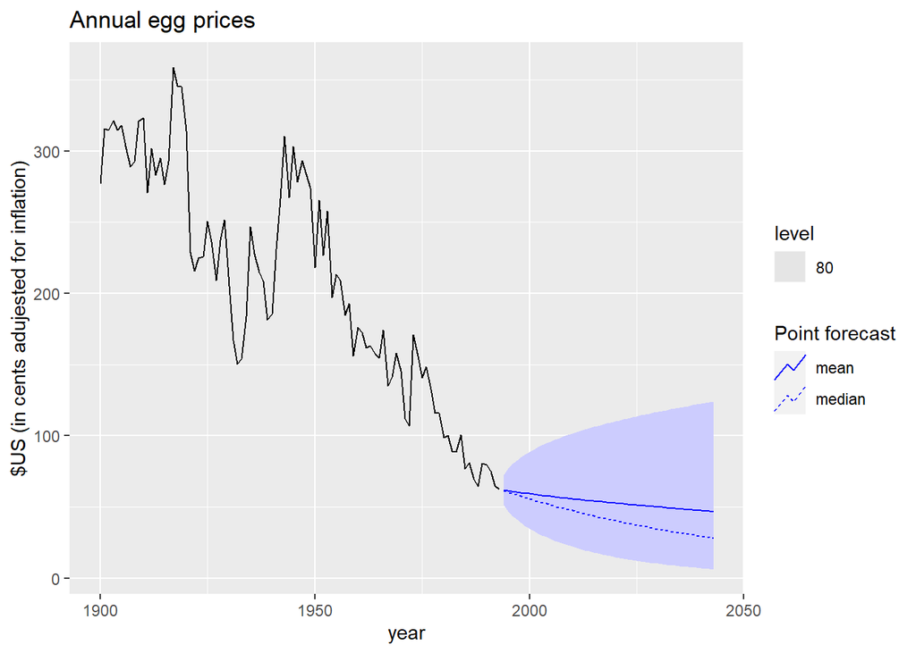

```r
prices %>%
    filter(!is.na(eggs)) %>%
    model(RW(log(eggs) ~ drift())) %>%
    forecast(h = 50) %>%
    autoplot(prices %>% filter(!is.na(eggs)), level = 80, point_forecast = lst(mean, median)) +
    labs(title = "Annual egg prices",
         y = "$US (in cents adujested for inflation)")
```

점선은 중간값을 나타내고 실선은 평균값을 나타내고 있다.  
어떤 식으로 한쪽으로 치우친(skewed) 예측 분포가 평균값을 끌어올리는지 알 수 있다.  
이렇게 올라간 것은 bias-adjustment를 해주었기 때문이다.

Bias-adjusted forecast 평균값은 `fable` package에서 자동적으로 계산된다.  
예측 중간값(bias-adjustment가 적용되기 전 예측값)은 `median()`함수를 사용하여 생성된 distribution열에서 확인이 가능하다.